# Zestaw 2

Amelia Madej

2023-10-31

# Potrzebne pakiety:

```r
library(tidyr)
library(dplyr)
library(gapminder)
library(ggplot2)
library(MASS)
library(robustbase)
library(psych)
```

# Zadanie 1

Stosuję funkcję `lapply()` dla listy `lista2`, aby obliczyć podstawowe statystyki opisowe. Wykorzystuję `mean()`, `sd()` oraz `quantile()`. Argument `na.rm == T` pozwala na usunięcie wartości brakujących `NA` z zestawu danych.

```r
lista2 <- list(dane1 = c(NA, 1:10),
               dane2 = c(-5:5, NA))
lista2
```

```
## $dane1
##  [1] NA  1  2  3  4  5  6  7  8  9 10
##
## $dane2
##  [1] -5 -4 -3 -2 -1  0  1  2  3  4  5 NA
```

```r
# Liczę średnią
lapply(lista2, mean, na.rm = T)
```

```
## $dane1
## [1] 5.5
##
## $dane2
## [1] 0
```

```r
# Liczę odchylenie standardowe
lapply(lista2, sd, na.rm = T)
```

```
## $dane1
## [1] 3.02765
##
## $dane2
## [1] 3.316625
```

```r
# Liczę kwantyle
lapply(lista2, quantile, na.rm = T)
```

```
## $dane1
##    0%   25%   50%   75%  100%
##  1.00  3.25  5.50  7.75 10.00
##
## $dane2
##   0%  25%  50%  75% 100%
## -5.0 -2.5  0.0  2.5  5.0
```

# Zadanie 2

Używam funkcji `sapply()`, aby obliczyć `max()` i `min()` z zestawu danych `lista4`.

```r
lista4 <- list(dane1 = 20:1,
               dane2 = 1:10,
               dane3 = 1:5)

# Liczę maximum
sapply(lista4, max)
```

```
## dane1 dane2 dane3
##    20    10     5
```

```r
# Liczę minimum
sapply(lista4, min)
```

```
## dane1 dane2 dane3
##     1     1     1
```

- Funkcja `lapply()` zwraca listę tej samej długości co X, gdzie każdy element tej listy jest wynikiem zastosowania funkcji FUN do odpowiadającego elementu X. Natomiast funkcja `sapply()` jest bardziej przyjazną dla użytkownika wersją, która domyślnie zwraca wektor lub macierz.
- Buduję funkcję mierzącą współczynnik zmienności `v` według wzoru:

$$v = \frac{sd()}{mean()}$$

```r
v <- function(x){
  v = sd(x)/mean(x)
  return(v)}
```

- Stosuję funkcję `sapply()` dla funkcji `v`.

```r
sapply(lista4, v)
```

```
##     dane1     dane2     dane3
## 0.5634362 0.5504819 0.5270463
```

# Zadanie 3

Funkcja `apply()` służy do stosowania określonej funkcji do wierszy lub kolumn w ramce danych lub macierzy. Od pozostałych funkcji różni się m.in. tym, że pozwala na iterację po wierszach (`MARGIN = 1`) lub kolumnach (`MARGIN = 2`) macierzy/ramki danych.

Przykładowe zastosowania:

- Obliczanie sumy sześcianów kolumn w macierzy:

```r
macierz <- matrix(1:6, ncol = 3)
macierz
```

```
##      [,1] [,2] [,3]
## [1,]    1    3    5
## [2,]    2    4    6
```

```r
suma_szescianow_kolumn <- apply(macierz, 2, function(col) sum(col^3))
suma_szescianow_kolumn
```

```
## [1]   9  91 341
```

```r
ramka1 <- data.frame(
  waga = c(70, 50, 66, 47, 53),
  wzrost = c(180, 155, 176, 160, 165))

srednia_waga_wzrost <- apply(ramka1, 2, mean)
srednia_waga_wzrost
```

```
##   waga wzrost
##   57.2  167.2
```

```r
ramka2 <- data.frame(
  temperatura = c(20, 19, 13, 25, 30),
  liczba_w_msc = c(10,9,3,4,5))

max_temp_liczba <- apply(ramka2, 2, max)
max_temp_liczba
```

```
##  temperatura liczba_w_msc
##           30           10
```

# Zadanie 4

- Oglądam zestaw `mtcars`.

```r
head(mtcars)
```

|  | mpg | cyl | disp | hp | drat | wt | qsec | vs | am | gear | carb |
| --- | --- | --- | --- | --- | --- | --- | --- | --- | --- | --- | --- |
| Mazda RX4 | 21.0 | 6 | 160 | 110 | 3.90 | 2.620 | 16.46 | 0 | 1 | 4 | 4 |
| Mazda RX4 Wag | 21.0 | 6 | 160 | 110 | 3.90 | 2.875 | 17.02 | 0 | 1 | 4 | 4 |
| Datsun 710 | 22.8 | 4 | 108 | 93 | 3.85 | 2.320 | 18.61 | 1 | 1 | 4 | 1 |
| Hornet 4 Drive | 21.4 | 6 | 258 | 110 | 3.08 | 3.215 | 19.44 | 1 | 0 | 3 | 1 |
| Hornet Sportabout | 18.7 | 8 | 360 | 175 | 3.15 | 3.440 | 17.02 | 0 | 0 | 3 | 2 |
| Valiant | 18.1 | 6 | 225 | 105 | 2.76 | 3.460 | 20.22 | 1 | 0 | 3 | 1 |

```r
str(mtcars)
```

```
## 'data.frame':    32 obs. of  11 variables:
##  $ mpg : num  21 21 22.8 21.4 18.7 18.1 14.3 24.4 22.8 19.2 ...
##  $ cyl : num  6 6 4 6 8 6 8 4 4 6 ...
##  $ disp: num  160 160 108 258 360 ...
##  $ hp  : num  110 110 93 110 175 105 245 62 95 123 ...
##  $ drat: num  3.9 3.9 3.85 3.08 3.15 2.76 3.21 3.69 3.92 3.92 ...
##  $ wt  : num  2.62 2.88 2.32 3.21 3.44 ...
##  $ qsec: num  16.5 17 18.6 19.4 17 ...
##  $ vs  : num  0 0 1 1 0 1 0 1 1 1 ...
##  $ am  : num  1 1 1 0 0 0 0 0 0 0 ...
##  $ gear: num  4 4 4 3 3 3 3 4 4 4 ...
##  $ carb: num  4 4 1 1 2 1 4 2 2 4 ...
```

- Wykorzystuję funkcję `tapply()` do uzyskania informacji o przeciętnym spalaniu w zależności od liczby cylindrów.

```r
srednie_spalanie <- tapply(mtcars$mpg, mtcars$cyl, mean)
srednie_spalanie
```

```
##        4        6        8
## 26.66364 19.74286 15.10000
```

- Wyświetlam podstawowe statystyki opisowe za pomocą funkcji `describeBy()`.

```r
statystyki_opisowe <- describeBy(mtcars$mpg, group = mtcars$cyl, mat = T)
statystyki_opisowe
```

|  | item | group1 | vars | n | mean | sd | median | trimmed | mad | min | max | range | skew | kurtosis | se |
| --- | --- | --- | --- | --- | --- | --- | --- | --- | --- | --- | --- | --- | --- | --- | --- |
| X11 | 1 | 4 | 1 | 11 | 26.66364 | 4.509828 | 26.0 | 26.44444 | 6.52344 | 21.4 | 33.9 | 12.5 | 0.2591965 | -1.6450119 | 1.3597642 |
| X12 | 2 | 6 | 1 | 7 | 19.74286 | 1.453567 | 19.7 | 19.74286 | 1.92738 | 17.8 | 21.4 | 3.6 | -0.1583137 | -1.9069714 | 0.5493967 |
| X13 | 3 | 8 | 1 | 14 | 15.10000 | 2.560048 | 15.2 | 15.15000 | 1.55673 | 10.4 | 19.2 | 8.8 | -0.3628186 | -0.5655154 | 0.6842016 |

# Zadanie 5

Wyświetlam dane przedstawione w ramce `anscombe` z pakietu `datasets`.

```r
head(anscombe)
```

|  | x1 | x2 | x3 | x4 | y1 | y2 | y3 | y4 |
| --- | --- | --- | --- | --- | --- | --- | --- | --- |
| 1 | 10 | 10 | 10 | 8 | 8.04 | 9.14 | 7.46 | 6.58 |
| 2 | 8 | 8 | 8 | 8 | 6.95 | 8.14 | 6.77 | 5.76 |
| 3 | 13 | 13 | 13 | 8 | 7.58 | 8.74 | 12.74 | 7.71 |
| 4 | 9 | 9 | 9 | 8 | 8.81 | 8.77 | 7.11 | 8.84 |
| 5 | 11 | 11 | 11 | 8 | 8.33 | 9.26 | 7.81 | 8.47 |
| 6 | 14 | 14 | 14 | 8 | 9.96 | 8.10 | 8.84 | 7.04 |

```r
str(anscombe)
```

```
## 'data.frame':    11 obs. of  8 variables:
##  $ x1: num  10 8 13 9 11 14 6 4 12 7 ...
##  $ x2: num  10 8 13 9 11 14 6 4 12 7 ...
##  $ x3: num  10 8 13 9 11 14 6 4 12 7 ...
##  $ x4: num  8 8 8 8 8 8 8 19 8 8 ...
##  $ y1: num  8.04 6.95 7.58 8.81 8.33 ...
##  $ y2: num  9.14 8.14 8.74 8.77 9.26 8.1 6.13 3.1 9.13 7.26 ...
##  $ y3: num  7.46 6.77 12.74 7.11 7.81 ...
##  $ y4: num  6.58 5.76 7.71 8.84 8.47 7.04 5.25 12.5 5.56 7.91 ...
```

Wyświetlam dane `fgl` z pakietu `MASS`.

```r
head(fgl)
```

|  | RI | Na | Mg | Al | Si | K | Ca | Ba | Fe | type |
| --- | --- | --- | --- | --- | --- | --- | --- | --- | --- | --- |
| 1 | 3.01 | 13.64 | 4.49 | 1.10 | 71.78 | 0.06 | 8.75 | 0 | 0.00 | WinF |
| 2 | -0.39 | 13.89 | 3.60 | 1.36 | 72.73 | 0.48 | 7.83 | 0 | 0.00 | WinF |
| 3 | -1.82 | 13.53 | 3.55 | 1.54 | 72.99 | 0.39 | 7.78 | 0 | 0.00 | WinF |
| 4 | -0.34 | 13.21 | 3.69 | 1.29 | 72.61 | 0.57 | 8.22 | 0 | 0.00 | WinF |
| 5 | -0.58 | 13.27 | 3.62 | 1.24 | 73.08 | 0.55 | 8.07 | 0 | 0.00 | WinF |
| 6 | -2.04 | 12.79 | 3.61 | 1.62 | 72.97 | 0.64 | 8.07 | 0 | 0.26 | WinF |

```r
str(fgl)
```

```
## 'data.frame':    214 obs. of  10 variables:
##  $ RI  : num  3.01 -0.39 -1.82 -0.34 -0.58 ...
##  $ Na  : num  13.6 13.9 13.5 13.2 13.3 ...
##  $ Mg  : num  4.49 3.6 3.55 3.69 3.62 3.61 3.6 3.61 3.58 3.6 ...
##  $ Al  : num  1.1 1.36 1.54 1.29 1.24 1.62 1.14 1.05 1.37 1.36 ...
##  $ Si  : num  71.8 72.7 73 72.6 73.1 ...
##  $ K   : num  0.06 0.48 0.39 0.57 0.55 0.64 0.58 0.57 0.56 0.57 ...
##  $ Ca  : num  8.75 7.83 7.78 8.22 8.07 8.07 8.17 8.24 8.3 8.4 ...
##  $ Ba  : num  0 0 0 0 0 0 0 0 0 0 ...
##  $ Fe  : num  0 0 0 0 0 0.26 0 0 0 0.11 ...
##  $ type: Factor w/ 6 levels "WinF","WinNF",..: 1 1 1 1 1 1 1 1 1 1 ...
```

Według mnie ciekawszym zestawem danych są dane `fgl`, ponieważ są to dane dotyczące fragmentów szkła zebranych podczas prac kryminalistycznych.

- Używam funkcji `sapply()` do wyznaczenia średnich we wszystkich kolumnach wybranej ramki danych.

**Uwaga!** Nie wykorzysztuję funkcji `apply()`, ponieważ jedna z kolumn nie jest numeryczna i przy użyciu powyższej funkcji nie zostają policzone średnie w kolumnach numerycznych.

```r
sapply(fgl,  mean)
```

```
##          RI          Na          Mg          Al          Si           K
##  0.36542056 13.40785047  2.68453271  1.44490654 72.65093458  0.49705607
##          Ca          Ba          Fe        type
##  8.95696262  0.17504673  0.05700935          NA
```

- Używam funkcji `str()` do sprawdzenia, które kolumny są numeryczne i powtarzam wcześniejszy podpunkt tylko do tych kolumn. Nie wyznaczam średnich dla kolumny `type`, ponieważ jest to zmienna `factor`.

```r
str(fgl)
```

```
## 'data.frame':    214 obs. of  10 variables:
##  $ RI  : num  3.01 -0.39 -1.82 -0.34 -0.58 ...
##  $ Na  : num  13.6 13.9 13.5 13.2 13.3 ...
##  $ Mg  : num  4.49 3.6 3.55 3.69 3.62 3.61 3.6 3.61 3.58 3.6 ...
##  $ Al  : num  1.1 1.36 1.54 1.29 1.24 1.62 1.14 1.05 1.37 1.36 ...
##  $ Si  : num  71.8 72.7 73 72.6 73.1 ...
##  $ K   : num  0.06 0.48 0.39 0.57 0.55 0.64 0.58 0.57 0.56 0.57 ...
##  $ Ca  : num  8.75 7.83 7.78 8.22 8.07 8.07 8.17 8.24 8.3 8.4 ...
##  $ Ba  : num  0 0 0 0 0 0 0 0 0 0 ...
##  $ Fe  : num  0 0 0 0 0 0.26 0 0 0 0.11 ...
##  $ type: Factor w/ 6 levels "WinF","WinNF",..: 1 1 1 1 1 1 1 1 1 1 ...
```

```r
srednie <- apply(fgl[1:9], 2, mean)
srednie
```

```
##          RI          Na          Mg          Al          Si           K
##  0.36542056 13.40785047  2.68453271  1.44490654 72.65093458  0.49705607
##          Ca          Ba          Fe
##  8.95696262  0.17504673  0.05700935
```

- Używam funkcji `apply()` do wyznaczenia mediany we wszystkich kolumnach ilościowych.

```r
mediany <- apply(fgl[1:9], 2, median)
mediany
```

```
##     RI     Na     Mg     Al     Si      K     Ca     Ba     Fe
## -0.320 13.300  3.480  1.360 72.790  0.555  8.600  0.000  0.000
```

- Dla której zmiennej widzimy największą różnicę między średnią a medianą? Do odpowiedzi na to pytanie wykorzystuję funkcję `which.max()`.

```r
roznica <- abs(srednie - mediany)
roznica
```

```
##         RI         Na         Mg         Al         Si          K         Ca
## 0.68542056 0.10785047 0.79546729 0.08490654 0.13906542 0.05794393 0.35696262
##         Ba         Fe
## 0.17504673 0.05700935
```

```r
cat("\nMaksymalną różnicę pomiędzy średnią, a medianą widzimy dla zmiennej '", colnames(fgl[which.max(roznica)]), "'.")
```

```
##
## Maksymalną różnicę pomiędzy średnią, a medianą widzimy dla zmiennej ' Mg '.
```

- Używam funkcji `apply()` do obliczenia odchylenia standardowego oraz współczynnika zmienności dla wszystkich kolumn ilościowych zestawu danych `fgl`.

```r
apply(fgl[1:9], 2, sd)
```

```
##        RI        Na        Mg        Al        Si         K        Ca        Ba
## 3.0368637 0.8166036 1.4424078 0.4992696 0.7745458 0.6521918 1.4231535 0.4972193
##        Fe
## 0.0974387
```

```r
v <- function(a){
  return(sd(a)/mean(a))}

apply(fgl[1:9], 2, v)
```

```
##         RI         Na         Mg         Al         Si          K         Ca
## 8.31059898 0.06090488 0.53730314 0.34553767 0.01066120 1.31210919 0.15888796
##         Ba         Fe
## 2.84049444 1.70917065
```

# Zadanie 6

Wykorzystuję pakiety `tidyr`, `dplyr` oraz `gapminder`.

- Zmieniam nazwy zmiennych, tj. zmienną `year` nazywam `rok`, a zmienną `gdpPercap` nazywam `PKB`.

```r
gapminder %>%
  rename(rok = year, PKB = gdpPercap)
```

| country | continent | rok | lifeExp | pop | PKB |
| --- | --- | --- | --- | --- | --- |
| Afghanistan | Asia | 1952 | 28.80100 | 8425333 | 779.4453 |
| Afghanistan | Asia | 1957 | 30.33200 | 9240934 | 820.8530 |
| Afghanistan | Asia | 1962 | 31.99700 | 10267083 | 853.1007 |
| Afghanistan | Asia | 1967 | 34.02000 | 11537966 | 836.1971 |
| Afghanistan | Asia | 1972 | 36.08800 | 13079460 | 739.9811 |
| Afghanistan | Asia | 1977 | 38.43800 | 14880372 | 786.1134 |
| Afghanistan | Asia | 1982 | 39.85400 | 12881816 | 978.0114 |
| Afghanistan | Asia | 1987 | 40.82200 | 13867957 | 852.3959 |
| Afghanistan | Asia | 1992 | 41.67400 | 16317921 | 649.3414 |
| Afghanistan | Asia | 1997 | 41.76300 | 22227415 | 635.3414 |

[output cut: 1694 more lines]

- Zmieniam wartości zmiennej `pop` tak, aby ludność była przedstawiona w milionach osób.

```r
pop_mln <- gapminder %>%
  mutate(pop = pop/1000000)
pop_mln
```

| country | continent | year | lifeExp | pop | gdpPercap |
| --- | --- | --- | --- | --- | --- |
| Afghanistan | Asia | 1952 | 28.80100 | 8.425333 | 779.4453 |
| Afghanistan | Asia | 1957 | 30.33200 | 9.240934 | 820.8530 |
| Afghanistan | Asia | 1962 | 31.99700 | 10.267083 | 853.1007 |
| Afghanistan | Asia | 1967 | 34.02000 | 11.537966 | 836.1971 |
| Afghanistan | Asia | 1972 | 36.08800 | 13.079460 | 739.9811 |
| Afghanistan | Asia | 1977 | 38.43800 | 14.880372 | 786.1134 |
| Afghanistan | Asia | 1982 | 39.85400 | 12.881816 | 978.0114 |
| Afghanistan | Asia | 1987 | 40.82200 | 13.867957 | 852.3959 |
| Afghanistan | Asia | 1992 | 41.67400 | 16.317921 | 649.3414 |
| Afghanistan | Asia | 1997 | 41.76300 | 22.227415 | 635.3414 |

[output cut: 1694 more lines]

- Wyświetlam wszystkie kraje afrykańskie, które w roku 1957 miały PKB większe niż 12000$.

```r
kraje_afrykanskie <- gapminder %>%
  filter(year == 1957,
         gdpPercap > 12000,
         continent == "Africa")

kraje_afrykanskie
```

| country | continent | year | lifeExp | pop | gdpPercap |
| --- | --- | --- | --- | --- | --- |

- Rysuję wykres, który pokazuje ile tych krajów (z powyższego podpunktu) było w każdym roku badania.

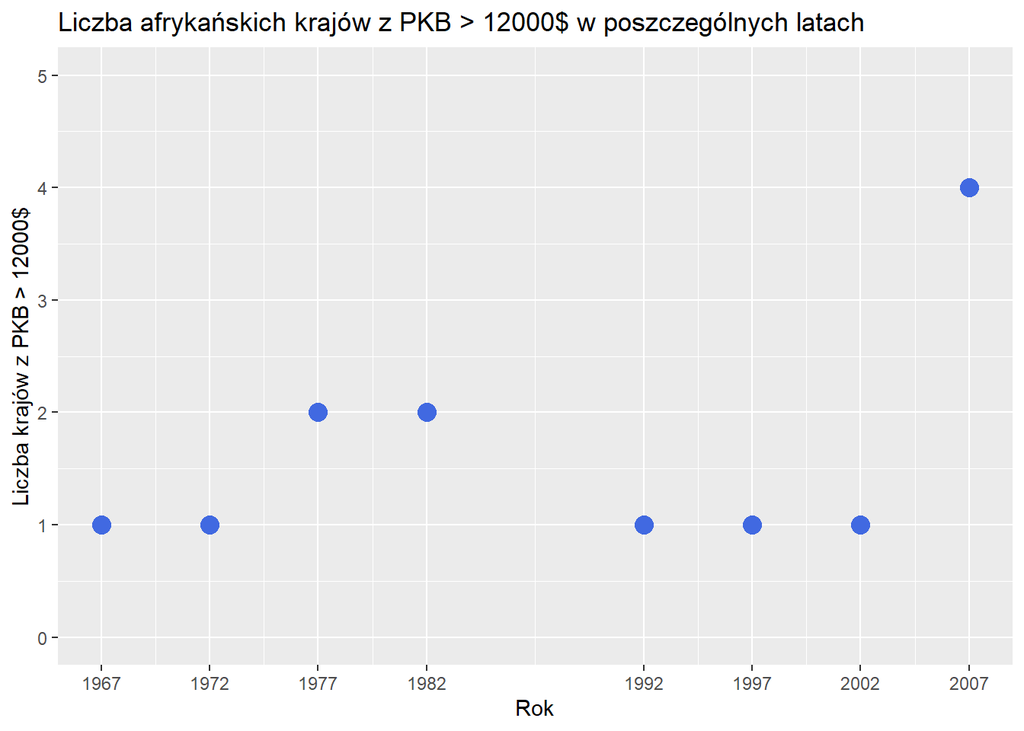

```r
liczba_krajow_w_kazdym_roku <- gapminder %>%
  filter(gdpPercap > 12000,
         continent == "Africa") %>%
  group_by(year) %>%
  summarize(liczba_krajow = n())

library(ggplot2)
ggplot(liczba_krajow_w_kazdym_roku, aes(x = year, y = liczba_krajow)) +
  geom_point(size = 4,
            col = 'royalblue') +
  labs(x = "Rok",
       y = "Liczba krajów z PKB > 12000$") +
  scale_x_continuous(breaks = unique(liczba_krajow_w_kazdym_roku$year)) +
  ggtitle("Liczba afrykańskich krajów z PKB > 12000$ w poszczególnych latach")+
  scale_y_continuous(limits = c(0, max(liczba_krajow_w_kazdym_roku$liczba_krajow) + 1))
```

- Wyświetlam kraje spoza Afryki, które w roku 1962 miały PKB mniejsze od 750$.

```r
kraje_1962 <- gapminder %>%
  filter(continent !="Africa",
         year == 1962,
         gdpPercap < 750)

kraje_1962
```

| country | continent | year | lifeExp | pop | gdpPercap |
| --- | --- | --- | --- | --- | --- |
| Bangladesh | Asia | 1962 | 41.21600 | 56839289 | 686.3416 |
| Cambodia | Asia | 1962 | 43.41500 | 6083619 | 496.9136 |
| China | Asia | 1962 | 44.50136 | 665770000 | 487.6740 |
| India | Asia | 1962 | 43.60500 | 454000000 | 658.3472 |
| Myanmar | Asia | 1962 | 45.10800 | 23634436 | 388.0000 |
| Nepal | Asia | 1962 | 39.39300 | 10332057 | 652.3969 |

- Na przykładzie lat 1952, 1977 i 2002 sprawdzam, ile wynosiła przeciętna długość życia w Polsce.

```r
dl_zycia_pl <- gapminder %>%
  dplyr::select(country, year, lifeExp) %>%
  filter(country == "Poland",
         year %in% c(1952, 1977, 2002))

dl_zycia_pl
```

| country | year | lifeExp |
| --- | --- | --- |
| Poland | 1952 | 61.31 |
| Poland | 1977 | 70.67 |
| Poland | 2002 | 74.67 |

- Wyświetlam porównanie przedstawiające państwa Ameryk, w których przeciętna długość życia była większa niż w Polsce w wybranych latach.

```r
dl_zycia_ameryki <- gapminder %>%
    filter(year %in% c(1952, 1977, 2002),
         continent == "Americas") %>%
    dplyr::select(country, year, lifeExp)

dl_zycia_ameryki
```

| country | year | lifeExp |
| --- | --- | --- |
| Argentina | 1952 | 62.485 |
| Argentina | 1977 | 68.481 |
| Argentina | 2002 | 74.340 |
| Bolivia | 1952 | 40.414 |
| Bolivia | 1977 | 50.023 |
| Bolivia | 2002 | 63.883 |
| Brazil | 1952 | 50.917 |
| Brazil | 1977 | 61.489 |
| Brazil | 2002 | 71.006 |
| Canada | 1952 | 68.750 |

[output cut: 65 more lines]

```r
porownanie <- full_join(dl_zycia_pl, dl_zycia_ameryki, by = c("year")) %>%
  filter(lifeExp.x < lifeExp.y)

porownanie
```

| country.x | year | lifeExp.x | country.y | lifeExp.y |
| --- | --- | --- | --- | --- |
| Poland | 1952 | 61.31 | Argentina | 62.485 |
| Poland | 1952 | 61.31 | Canada | 68.750 |
| Poland | 1952 | 61.31 | Paraguay | 62.649 |
| Poland | 1952 | 61.31 | Puerto Rico | 64.280 |
| Poland | 1952 | 61.31 | United States | 68.440 |
| Poland | 1952 | 61.31 | Uruguay | 66.071 |
| Poland | 1977 | 70.67 | Canada | 74.210 |
| Poland | 1977 | 70.67 | Costa Rica | 70.750 |
| Poland | 1977 | 70.67 | Cuba | 72.649 |
| Poland | 1977 | 70.67 | Puerto Rico | 73.440 |

[output cut: 10 more lines]

Porównanie z krajami Ameryki Północnej i Południowej może pomóc w zrozumieniu, jak czynniki historyczne, polityczne i gospodarcze wpływały na długość życia w Polsce w tych okresach.

- Wyznaczam podstawowe statystyki opisowe dot. wielkości populacji na różnych kontynentach w roku 2007. Posługuję się funkcjami `group_by()` i `summarize()`.

```r
pop_kontynenty <- gapminder %>%
  filter(year == 2007) %>%
  rename(Kontynent = continent) %>%
  group_by(Kontynent) %>%
  summarize(Średnia = mean(pop),
            Mediana = median(pop),
            Min = min(pop),
            Max = max(pop),
            Odchylenie_standardowe = sd(pop))

pop_kontynenty
```

| Kontynent | Średnia | Mediana | Min | Max | Odchylenie_standardowe |
| --- | --- | --- | --- | --- | --- |
| Africa | 17875763 | 10093311 | 199579 | 135031164 | 24917726 |
| Americas | 35954847 | 9319622 | 1056608 | 301139947 | 68833781 |
| Asia | 115513752 | 24821286 | 708573 | 1318683096 | 289673399 |
| Europe | 19536618 | 9493598 | 301931 | 82400996 | 23624744 |
| Oceania | 12274974 | 12274974 | 4115771 | 20434176 | 11538855 |

- Wśród krajów o PKB niższym od 5000$ (rozważam dane za rok 1977), wyznaczam po trzy kraje z Afryki, Europy i Azji, w których spodziewana długość życia jest największa.

```r
po_trzy_kraje <- gapminder %>%
  filter(gdpPercap < 5000,
         year == 1977,
         continent %in% c("Africa", "Asia", "Europe")) %>%
  group_by(continent) %>%
  top_n(3, lifeExp) %>%
  arrange(continent, desc(lifeExp))

po_trzy_kraje
```

| country | continent | year | lifeExp | pop | gdpPercap |
| --- | --- | --- | --- | --- | --- |
| Reunion | Africa | 1977 | 67.064 | 492095 | 4319.804 |
| Mauritius | Africa | 1977 | 64.930 | 913025 | 3710.983 |
| Tunisia | Africa | 1977 | 59.837 | 6005061 | 3120.877 |
| Korea, Dem. Rep. | Asia | 1977 | 67.159 | 16325320 | 4106.301 |
| Sri Lanka | Asia | 1977 | 65.949 | 14116836 | 1348.776 |
| Malaysia | Asia | 1977 | 65.256 | 12845381 | 3827.922 |
| Bosnia and Herzegovina | Europe | 1977 | 69.860 | 4086000 | 3528.481 |
| Albania | Europe | 1977 | 68.930 | 2509048 | 3533.004 |
| Turkey | Europe | 1977 | 59.507 | 42404033 | 4269.122 |

- Filtruję dane z roku 1987 dla krajów europejskich. Dodaję zmienną `system`, która przyjmuje trzy wartości: `RWPG` dla krajów RWPG, `UE` dla krajów Unii Europejskiej oraz `Inne` dla pozostałych krajów. Następnie wyznaczam podstawowe statystyki opisowe (średnia, mediana, odchylenie standardowe, Q1 i Q3).

```r
RWPG <- c("Bulgaria", "Czech Republic", "Slovakia", "Poland", "Romania", "Hungary", "Russia", "Ukraine", "Belarus", "Uzbekistan", "Kazachstan", "Georgia", "Azerbaijan", "Lithuania", "Moldova", "Latvia", "Kyrgyzstan", "Tajikistan", "Armenia", "Turkmenistan", "Estonia")

UE_1987 <- c("Belgium", "Denmark", "France", "Germany", "Greece", "Ireland", "Italy", "Luxembourg", "Netherlands", "Portugal", "Spain")


systemy <- gapminder %>%
  filter(year == 1987,
         continent == "Europe") %>%
  mutate(System = ifelse(country %in% RWPG, "RWPG", ifelse(country %in% UE_1987, "UE", "Inne")))

systemy
```

| country | continent | year | lifeExp | pop | gdpPercap | System |
| --- | --- | --- | --- | --- | --- | --- |
| Albania | Europe | 1987 | 72.000 | 3075321 | 3738.933 | Inne |
| Austria | Europe | 1987 | 74.940 | 7578903 | 23687.826 | Inne |
| Belgium | Europe | 1987 | 75.350 | 9870200 | 22525.563 | UE |
| Bosnia and Herzegovina | Europe | 1987 | 71.140 | 4338977 | 4314.115 | Inne |
| Bulgaria | Europe | 1987 | 71.340 | 8971958 | 8239.855 | RWPG |
| Croatia | Europe | 1987 | 71.520 | 4484310 | 13822.584 | Inne |
| Czech Republic | Europe | 1987 | 71.580 | 10311597 | 16310.443 | RWPG |
| Denmark | Europe | 1987 | 74.800 | 5127024 | 25116.176 | UE |
| Finland | Europe | 1987 | 74.830 | 4931729 | 21141.012 | Inne |
| France | Europe | 1987 | 76.340 | 55630100 | 22066.442 | UE |

[output cut: 20 more lines]

```r
systemy_statystyki <- systemy %>%
  group_by(System) %>%
  summarize(średnia_pop = mean(pop),
            średnia_dl_zycia = mean(lifeExp),
            średnia_gdp = mean(gdpPercap),
            mediana_pop = median(pop),
            mediana_dl_zycia = median(lifeExp),
            mediana_gdp = median(gdpPercap),
            odchylenie_standardowe_pop = sd(pop),
            odchylenie_standardowe_dl_zycia = sd(lifeExp),
            odchylenie_standardowe_gdp = sd(gdpPercap),
            Q1_pop = quantile(pop, 0.25),
            Q3_pop = quantile(pop, 0.75),
            Q1_dl_zycia = quantile(lifeExp, 0.25),
            Q3_dl_zycia = quantile(lifeExp, 0.75),
            Q1_gdp = quantile(gdpPercap, 0.25),
            Q3_gdp = quantile(gdpPercap, 0.75))

systemy_statystyki
```

| System | średnia_pop | średnia_dl_zycia | średnia_gdp | mediana_pop | mediana_dl_zycia | mediana_gdp | odchylenie_standardowe_pop | odchylenie_standardowe_dl_zycia | odchylenie_standardowe_gdp | Q1_pop | Q3_pop | Q1_dl_zycia | Q3_dl_zycia | Q1_gdp | Q3_gdp |
| --- | --- | --- | --- | --- | --- | --- | --- | --- | --- | --- | --- | --- | --- | --- | --- |
| Inne | 11381320 | 73.31187 | 17607.35 | 4931729 | 74.830 | 18678.535 | 17887655 | 3.6677664 | 9075.183 | 3630734 | 8000153 | 71.36900 | 75.4485 | 11884.889 | 23637.38 |
| RWPG | 18064675 | 70.60200 | 11263.08 | 10612740 | 70.980 | 9696.273 | 12316914 | 0.9794999 | 3346.503 | 10311597 | 22686371 | 69.58000 | 71.3400 | 9082.351 | 12986.48 |
| UE | 28205098 | 75.65770 | 19600.36 | 12319884 | 75.845 | 20636.838 | 26788568 | 1.0910350 | 4590.911 | 9881472 | 51442751 | 74.81175 | 76.6075 | 15853.869 | 23369.88 |

# Zadanie 7

Na jednym wykresie liniowym rysuję, jak w rozważanych latach zmieniała się oczekiwana długość życia w trzech wybranych przeze mnie krajach afrykańskich: `Madagaskar`, `Lesotho` oraz `Zimbabwe`. Przekształcam odpowiednie dane do postaci szerokiej używając funkcji `spread()` z pakietu `tidyr`.

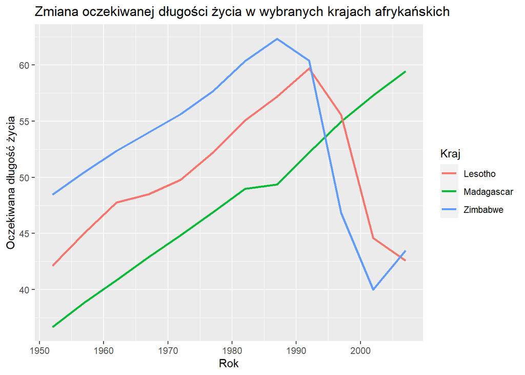

```r
dane_szerokie <- gapminder %>%
  filter(country %in% c("Madagascar",
                        "Lesotho",
                        "Zimbabwe")) %>%
  dplyr::select(country, year, lifeExp) %>%
  spread(country, lifeExp)


dane_szerokie %>%
  ggplot() +
  geom_line(mapping = aes(x = year,
                          y = Madagascar,
                          color = "Madagascar"),
            size = 1) +
  geom_line(mapping = aes(x = year,
                          y = Lesotho,
                          color = "Lesotho"),
            size = 1) +
  geom_line(mapping = aes(x = year,
                          y = Zimbabwe,
                          color = "Zimbabwe"),
            size = 1) +
  labs(x = "Rok",
       y = "Oczekiwana długość życia",
       title = "Zmiana oczekiwanej długości życia w wybranych krajach afrykańskich",
       color = "Kraj")
```

# Zadanie 8

Funkcja `set.seed()` służy do inicjowania generatora liczb losowych w określonej początkowej wartości (ziarno), co pozwala na kontrolowane generowanie tych samych losowych wyników w kolejnych próbach. Warto zastanowić się nad jej użyciem, gdy potrzebujemy powtarzalności i kontrolowalności wyników losowych.

- Wykorzystuję funkcję `sample()` do symulacji rzut kostką sześcienną. Rzucamy ową kostką 2, 10, 50, 100 i 1000 razy. Następnie wykorzystuję funkcję `table()` do tego, by sprawdzić, jakie liczby uzyskałam. Kolejno, Wykorzystuję funkcję `mean()`, by wyznaczyć średnią liczbę oczek w doświadczeniu.

```r
set.seed(123)

liczba_rzutow <- c(2, 10, 50, 100, 1000)

for (n in liczba_rzutow) {
  rzuty <- sample(1:6, n, replace = T)
  wynik <- table(rzuty)

  srednia <- mean(rzuty)

  cat(paste("Liczba rzutów:", n, "\n"))
  print(wynik)
  cat(paste("Średnia liczba oczek:", srednia, "\n\n"))
}
```

```
## Liczba rzutów: 2
## rzuty
## 3 6
## 1 1
## Średnia liczba oczek: 4.5
##
## Liczba rzutów: 10
## rzuty
## 1 2 3 4 5 6
## 1 2 2 1 1 3
## Średnia liczba oczek: 3.8
##
## Liczba rzutów: 50
## rzuty
##  1  2  3  4  5  6
## 12  8  9  7 10  4
## Średnia liczba oczek: 3.14
##
## Liczba rzutów: 100
## rzuty
##  1  2  3  4  5  6
## 13 13 17 17 11 29
## Średnia liczba oczek: 3.87
##
## Liczba rzutów: 1000
## rzuty
##   1   2   3   4   5   6
## 172 175 161 153 174 165
## Średnia liczba oczek: 3.477
```

Symulacja `Monte Carlo` polega na stworzeniu modelu uwzględniającego losowe czynniki, powtarzaniu eksperymentu z różnymi losowymi danymi i analizie wyników w celu uzyskania przybliżonych rezultatów.

- Dwa zespoły NBA, Chicago Bulls i NY Knicks, rozgrywają serię play-off składającą się z siedmiu meczów. Knicks są lepsi i mają 65% szans na wygranie każdego meczu. Rywalizacja toczy się do czterech zwycięstw. Przeprowadzam 10000 symulacji i sprawdzam jak często NY wygra rywalizację.

```r
set.seed(123)

symulacja <- function(liczba_meczy, liczba_symulacji){

  liczba_wygranych <- 0

  for(i in 1:liczba_symulacji){

    play_off_NY <- sample(c(0, 1), liczba_meczy, replace = T, prob = c(0.35, 0.65))

    if(sum(play_off_NY) >= 4){
      liczba_wygranych <- liczba_wygranych + 1
    }
  }

  return(liczba_wygranych)
}

l_meczy <- 7
l_symulacji <- 10000

rywalizacja <- symulacja(l_meczy, l_symulacji)
rywalizacja
```

```
## [1] 8054
```

```r
procent_wygranych <- rywalizacja / l_symulacji * 100

cat(paste("NY Knicks wygrało serię w ", procent_wygranych, "% symulacji."))
```

```
## NY Knicks wygrało serię w  80.54 % symulacji.
```

# Zadanie 9

Biorę ramkę danych `mammals` z pakietu `MASS`, która zawiera informacje o masie ciała i masie mózgu dla 62 wybranych zwierząt. A także dane, które znajdują się w ramce danych `Animals2` zamieszczone w pakiecie `robustbase`. W obu przypadkach nazwy wierszy identyfikują zwierzęta, a celem ćwiczenia jest zbadanie różnic między zwierzętami scharakteryzowanymi w obu zestawach danych.

- Funkcja `rownames()` zwraca wektor nazw wierszy dla ramki danych, a funkcja `intersect()` wyznacza część wspólną dwóch zestawów, zwracając wektor ich wspólnych elementów. Korzystając z tych funkcji, konstruuję i wyświetla, wektor `zwierzaki` nazw zwierząt wspólnych dla obu ramek danych.

```r
zwierzaki <- intersect(rownames(mammals), rownames(Animals2))
zwierzaki
```

```
##  [1] "Owl monkey"                "Mountain beaver"
##  [3] "Cow"                       "Grey wolf"
##  [5] "Goat"                      "Roe deer"
##  [7] "Guinea pig"                "Verbet"
##  [9] "Chinchilla"                "Ground squirrel"
## [11] "African giant pouched rat" "Lesser short-tailed shrew"
## [13] "Star-nosed mole"           "Nine-banded armadillo"
## [15] "Tree hyrax"                "N.A. opossum"
## [17] "Asian elephant"            "Big brown bat"
## [19] "Donkey"                    "Horse"
## [21] "European hedgehog"         "Cat"
## [23] "Galago"                    "Genet"
## [25] "Giraffe"                   "Gorilla"
## [27] "Grey seal"                 "Rock hyrax-a"
## [29] "Human"                     "African elephant"
## [31] "Water opossum"             "Rhesus monkey"
## [33] "Kangaroo"                  "Yellow-bellied marmot"
## [35] "Golden hamster"            "Mouse"
## [37] "Little brown bat"          "Slow loris"
## [39] "Okapi"                     "Rabbit"
## [41] "Sheep"                     "Jaguar"
## [43] "Chimpanzee"                "Baboon"
## [45] "Desert hedgehog"           "Giant armadillo"
## [47] "Rock hyrax-b"              "Raccoon"
## [49] "Rat"                       "E. American mole"
## [51] "Musk shrew"                "Pig"
## [53] "Echidna"                   "Brazilian tapir"
## [55] "Tenrec"                    "Phalanger"
## [57] "Tree shrew"                "Red fox"
```

```r
length(zwierzaki)
```

```
## [1] 58
```

- Funkcja `setdiff()` zwraca wektor elementów zawartych w jednym zbiorze, ale nie w drugim. Używam tej funkcji, aby wyświetlić zwierzęta obecne w zestawie `mammals`, których nie ma w zestawie `Animals2`.

```r
brak_w_Animals2 <- setdiff(x = rownames(mammals), y = rownames(Animals2))
brak_w_Animals2
```

```
## [1] "Arctic fox"             "Arctic ground squirrel" "Patas monkey"
## [4] "Mole rat"
```

- Natępnie używam funkcji `setdiff()`, aby wyświetlić zwierzęta obecne w `Animals2`, które nie występują w zestawie `mammals`.

```r
brak_w_mammals <- setdiff(x = rownames(Animals2), y = rownames(mammals))
brak_w_mammals
```

```
## [1] "Dipliodocus"           "Potar monkey"          "Triceratops"
## [4] "Brachiosaurus"         "Mole"                  "Artic fox"
## [7] "Artic ground squirrel"
```

# Zadanie 10

- Stosuję funkcji `qnorm()` by wyznaczyć `5%` i `95%` kwantyl dla rozkładu N(0,1).

```r
kwantyl_5_norm <- qnorm(0.05)
kwantyl_5_norm
```

```
## [1] -1.644854
```

```r
kwantyl_95_norm <- qnorm(0.95)
kwantyl_95_norm
```

```
## [1] 1.644854
```

- Wykorzystuję funkcję `qt()`, by wyznaczyć `5%` i `95%` kwantyl dla rozkładu t-Studenta.

**Uwaga!** Zakładam, że liczba stopni swobody wynosi odpowiednio 1, 5, 10, 30, 50 i 1000.

```r
stopnie_swobody <- c(1, 5, 10, 30, 50, 1000)

kwantyl_5_t_studenta <- sapply(stopnie_swobody, function(df) qt(0.05, df))
kwantyl_95_t_studenta <- sapply(stopnie_swobody, function(df) qt(0.95, df))

kwantyle_t <- data.frame(st_swobody = stopnie_swobody,
                         kwantyl_5_t_studenta = kwantyl_5_t_studenta,
                         kwantyl_95_t_studenta = kwantyl_95_t_studenta)
kwantyle_t
```

| st_swobody | kwantyl_5_t_studenta | kwantyl_95_t_studenta |
| --- | --- | --- |
| 1 | -6.313752 | 6.313752 |
| 5 | -2.015048 | 2.015048 |
| 10 | -1.812461 | 1.812461 |
| 30 | -1.697261 | 1.697261 |
| 50 | -1.675905 | 1.675905 |
| 1000 | -1.646379 | 1.646379 |

Można zauważyć, że:

- Im większa próbka (więcej stopni swobody), tym bardziej rozkład t-Studenta przypomina rozkład normalny, a kwantyle stają się bardziej zbliżone do kwantyli rozkładu normalnego. Dla mniejszych próbek (mniej stopni swobody), kwantyle t-Studenta są bardziej rozproszone, co odzwierciedla większą zmienność w wynikach.